# Udacity R Project by Ren Wang

```
##    Min. 1st Qu.  Median    Mean 3rd Qu.    Max.
##  0.1200  0.3900  0.5200  0.5278  0.6400  1.5800
```

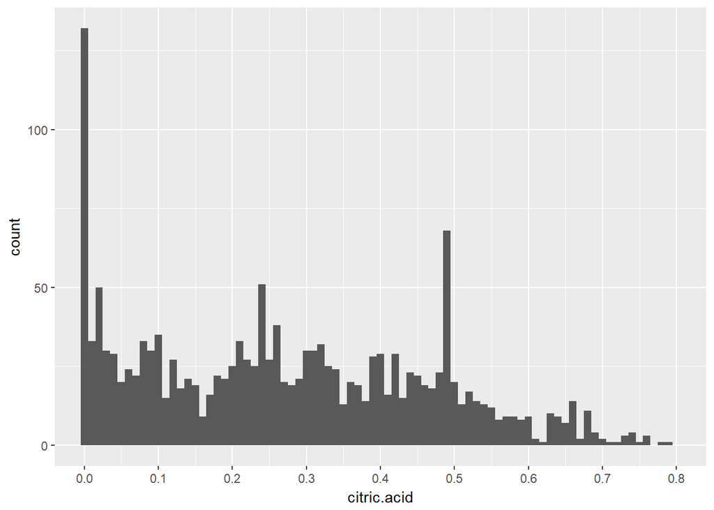

```
##    Min. 1st Qu.  Median    Mean 3rd Qu.    Max.
##   0.000   0.090   0.260   0.271   0.420   1.000
```

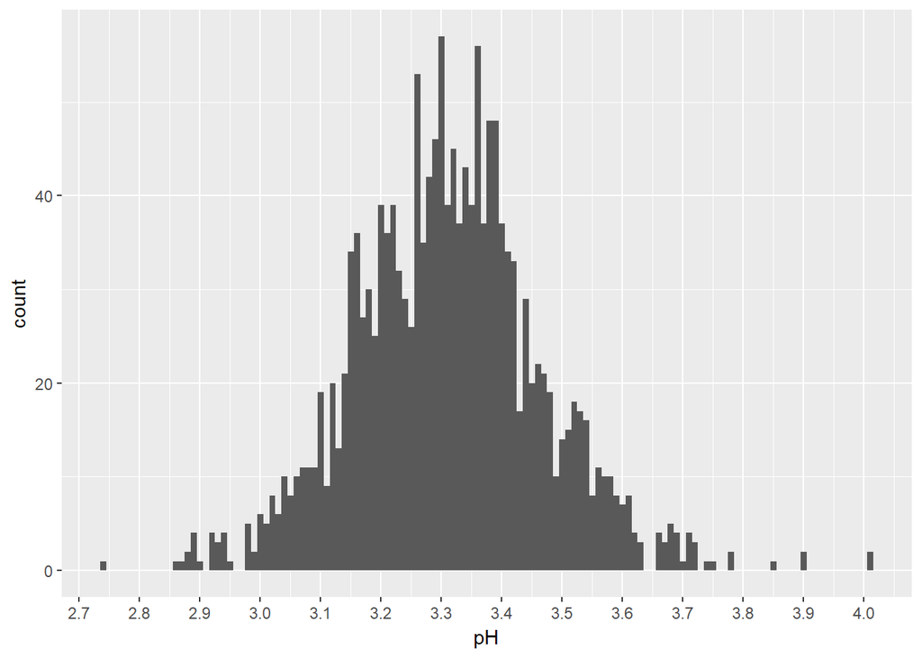

```
##    Min. 1st Qu.  Median    Mean 3rd Qu.    Max.
##   2.740   3.210   3.310   3.311   3.400   4.010
```

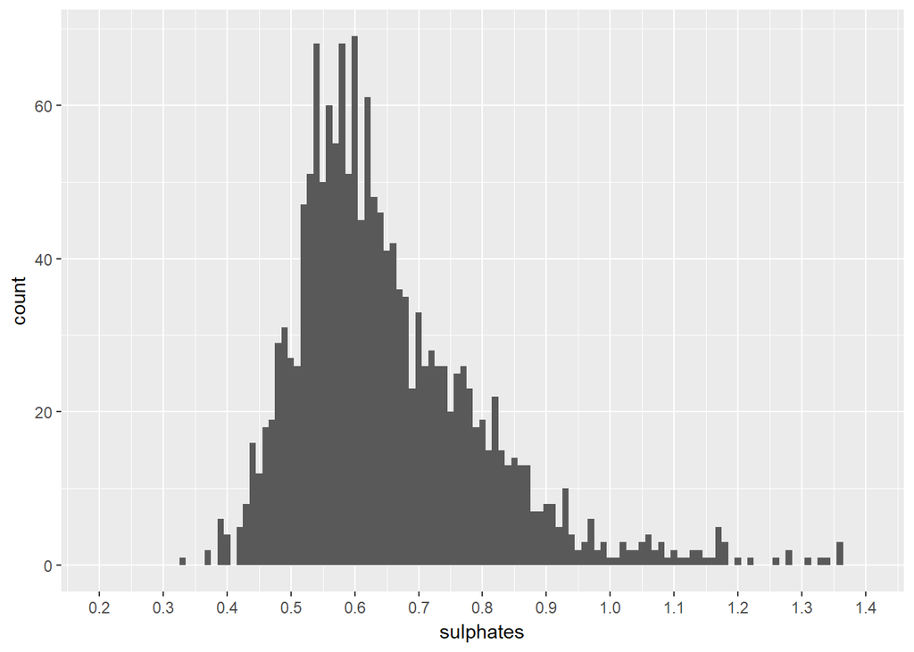

```
##
## 0.33 0.37 0.39  0.4 0.42 0.43 0.44 0.45 0.46 0.47 0.48 0.49  0.5 0.51 0.52
##    1    2    6    4    5    8   16   12   18   19   29   31   27   26   47
## 0.53 0.54 0.55 0.56 0.57 0.58 0.59  0.6 0.61 0.62 0.63 0.64 0.65 0.66 0.67
##   51   68   50   60   55   68   51   69   45   61   48   46   41   42   36
## 0.68 0.69  0.7 0.71 0.72 0.73 0.74 0.75 0.76 0.77 0.78 0.79  0.8 0.81 0.82
##   35   23   33   26   28   26   26   20   25   26   23   18   19   15   22
## 0.83 0.84 0.85 0.86 0.87 0.88 0.89  0.9 0.91 0.92 0.93 0.94 0.95 0.96 0.97
##   15   13   14   13   13    7    7    8    8    5   10    4    2    3    6
## 0.98 0.99    1 1.01 1.02 1.03 1.04 1.05 1.06 1.07 1.08 1.09  1.1 1.11 1.12
##    2    3    1    1    3    2    2    3    4    2    3    1    2    1    1
## 1.13 1.14 1.15 1.16 1.17 1.18  1.2 1.22 1.26 1.28 1.31 1.33 1.34 1.36 1.56
##    2    2    1    1    5    3    1    1    1    2    1    1    1    3    1
## 1.59 1.61 1.62 1.95 1.98    2
##    1    1    1    2    1    1
```

随后我探索了fixed.acidity,sulphates,ph和volatile.acid 几个变量的直方图。可以看到大部分红酒的Fixed.Acidity都处于7.1-9.2之间，最高为15.9，最低为4.6。红酒的Sulphates含量讲个以0.01左右逐渐变化， 因此我将binwidth设定为0.01以便更好的观测数据，我调整了X轴刻度并放大了0.2-1.4这个数据相对集中的区域。根据这两个红酒成分的图形，我们可以看出，红酒的质量的分布与各个成分的分布， 呈现出类似的状况。我设想红酒的质量与红酒成分之间可能会有较大的联系

# Univariate Analysis

### What is the structure of your dataset?

如图所示，本数据集中共含有13个变量，其中12个为有效变量，第一个为编号。本数据集共有1599个观测。变量包含fixed acidity,volatile acidity等数据。原数据集中所有的数据类型皆为数字类型。根据我们数据集文档， 我们可以发现红酒质量和酒精度都可以当做类别变量，在随后的分析中 将会将其变为类别变量。 一些观测结果： 1. 红酒质量最低评分为3分，最高为8分，平均分5.64分。 2. 50%的红酒都在10.2度以下 3. 所有的红酒都为酸性，酸碱值在2.74-4.01间

### What is/are the main feature(s) of interest in your dataset?

在本数据集中，我较为关注pH值，酒精含量，几个acidity的值以及sulphastes的含量，其中我最为关注的是ph值和几个acidity的值。尽管本数据集中，各个值可能都会对红酒质量有所影响，但是 我认为pH值和其他几个值进行综合考虑对构建红酒质量的预测模型有很大的帮助。

### What other features in the dataset do you think will help support your investigation into your feature(s) of interest?

红酒成分中的几个酸度，盐度，硫化物的含量都会对红酒的口味和质量有所影响。具体的哪一些含量影响更大需要进一步的研究。

### Did you create any new variables from existing variables in the dataset?

在此数据集中，随意组合几个acidity含量或者硫化物含量不会带来任何的意义，因为每一种红酒成分都对红酒的不同方面有所影响，简单的组合或者数据操作很难带来有意义 的新变量。但是我对quality进行了简单的分类组合，将小于5的红酒评分为差，<7的评分为可接受，剩余的为优秀。

### Of the features you investigated, were there any unusual distributions? Did you perform any operations on the data to tidy, adjust, or change the form of the data? If so, why did you do this?

对单变量分析的几个图，我进行了一些修剪和放大。在residual sugar和几个acidity的直方图绘制中，我去除了一些异常大的值，从数据汇总资料我们可以看出，在这几个值中，最大值和最小值之间差距非常大，只有少数 几个值落在这些极大量的区间。在绘图过程中，我减掉了这部分的极大值并且放大了数据较为集中的区间以便更好的观测数据的集中和变化趋势。

# Bivariate Plots Section

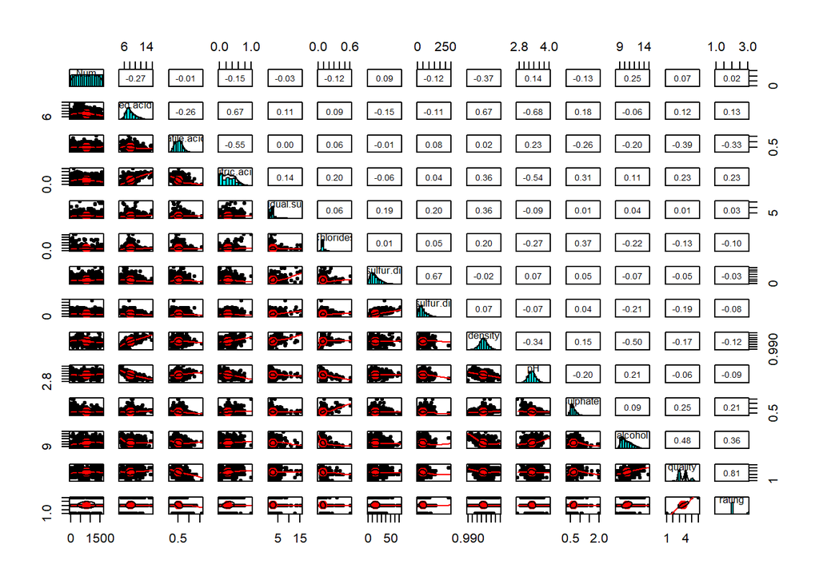

从图中我们可以看出，红酒质量与酒精度， sulphates,citric.acid等成分有相对较高的关系，这也和我之前的猜想相吻合。此外， 几个acidity之间，几个硫化物之间 也都有一些的关联度。

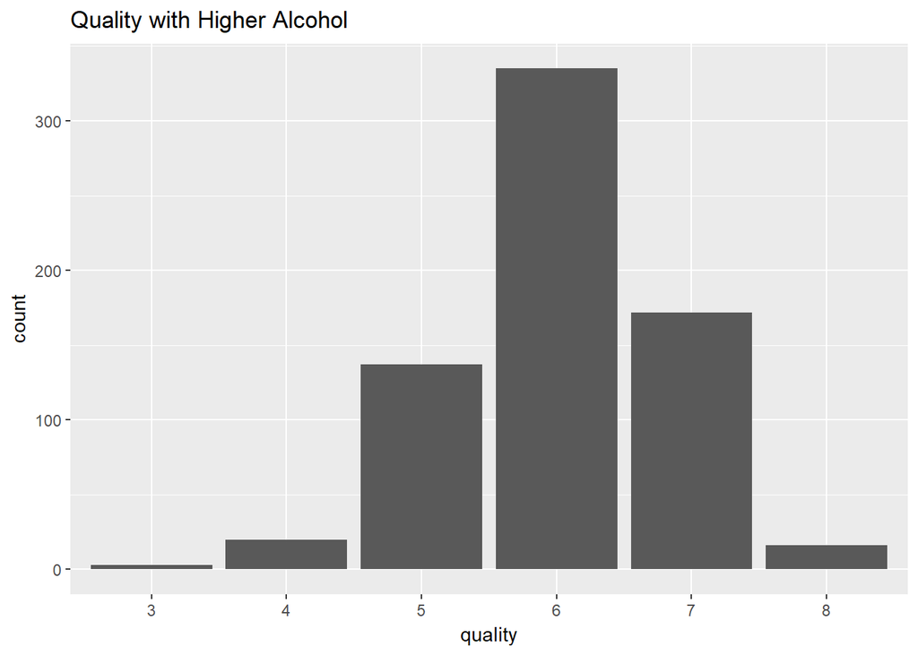

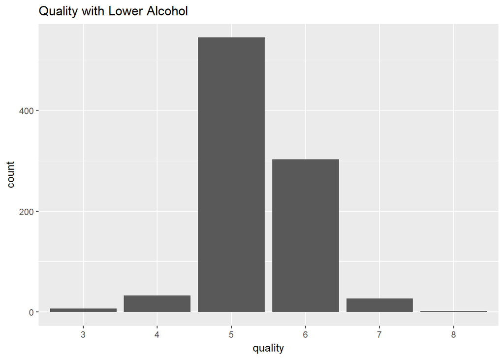

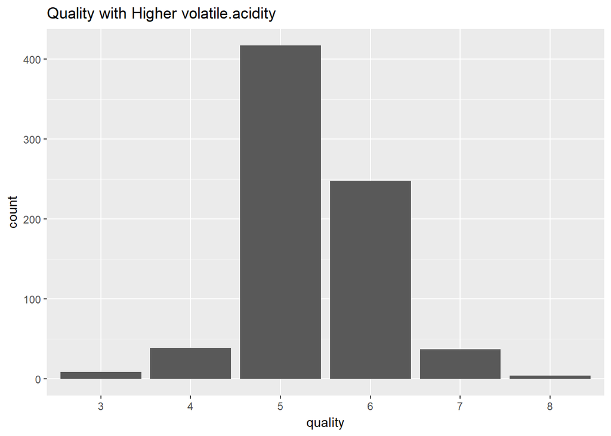

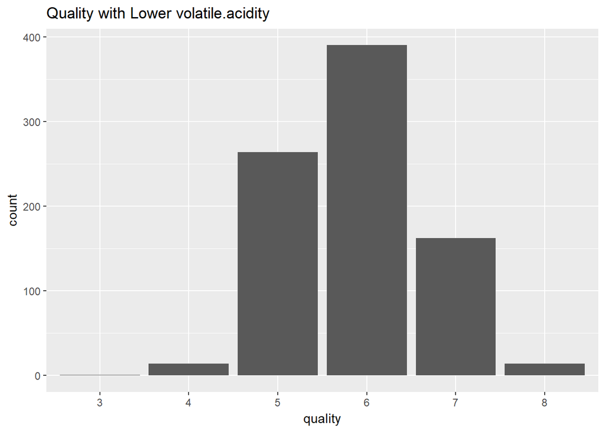

```
##    Min. 1st Qu.  Median    Mean 3rd Qu.    Max.
##  0.1200  0.3900  0.5200  0.5278  0.6400  1.5800
```

这部分，我探索了不同酒精度数的红酒的质量分布。在画图之前，我对原始数据就行了取子集操作，我根据酒精度的平均数就行了划分，大于平均数的为高酒精度，小于平均数的为低酒精度， 从图中我们可以看出低酒精度的红酒在高质量区间（7-8）的数量较少，而高酒精度的红酒在高质量区间数量较多。同理我们可以看出，低volatile acidity组有更高的红酒质量从图像中， 我怀疑红酒的质量和酒精含量以及volatile acidity有或多或少的联系。

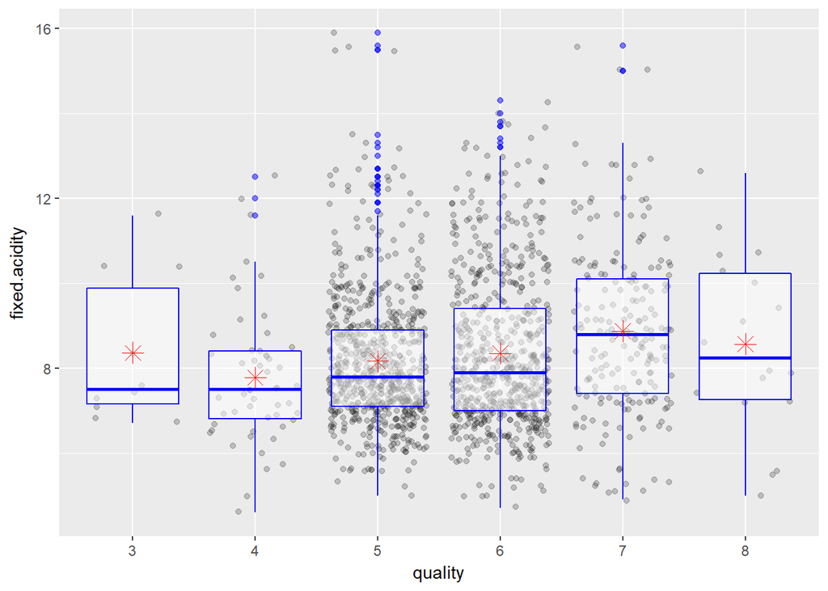

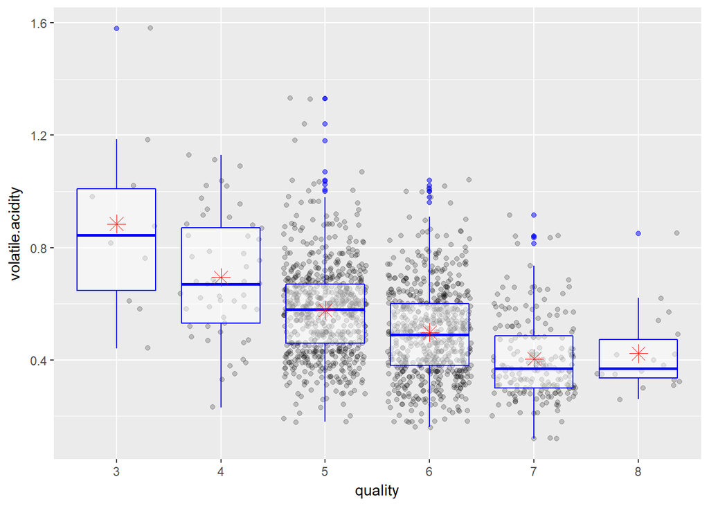

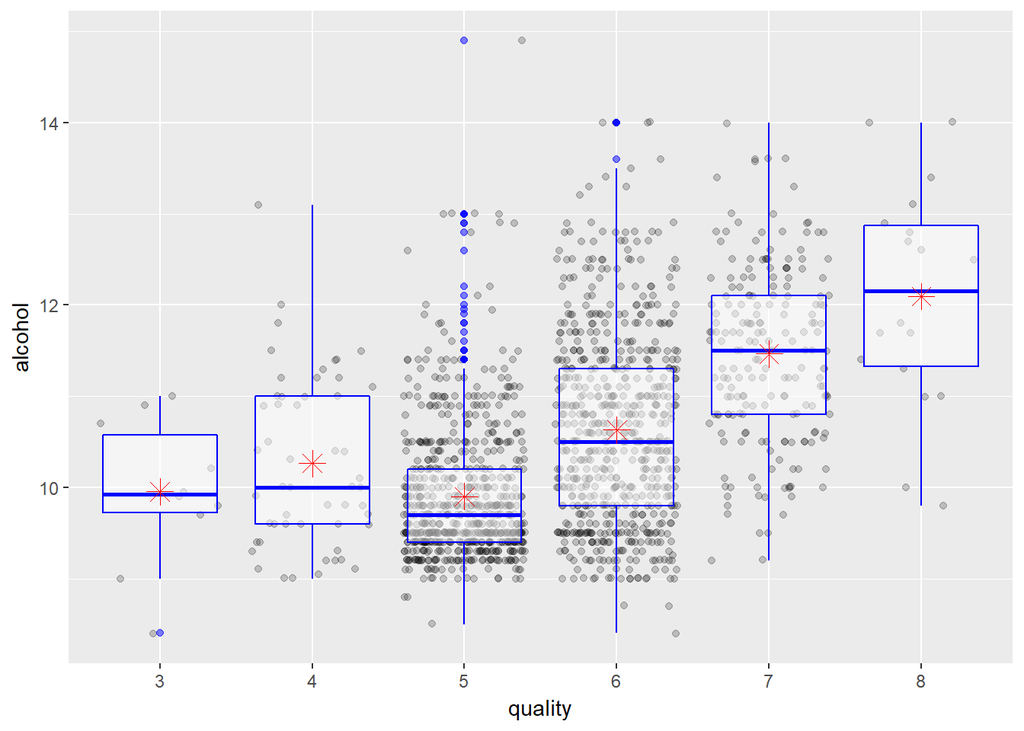

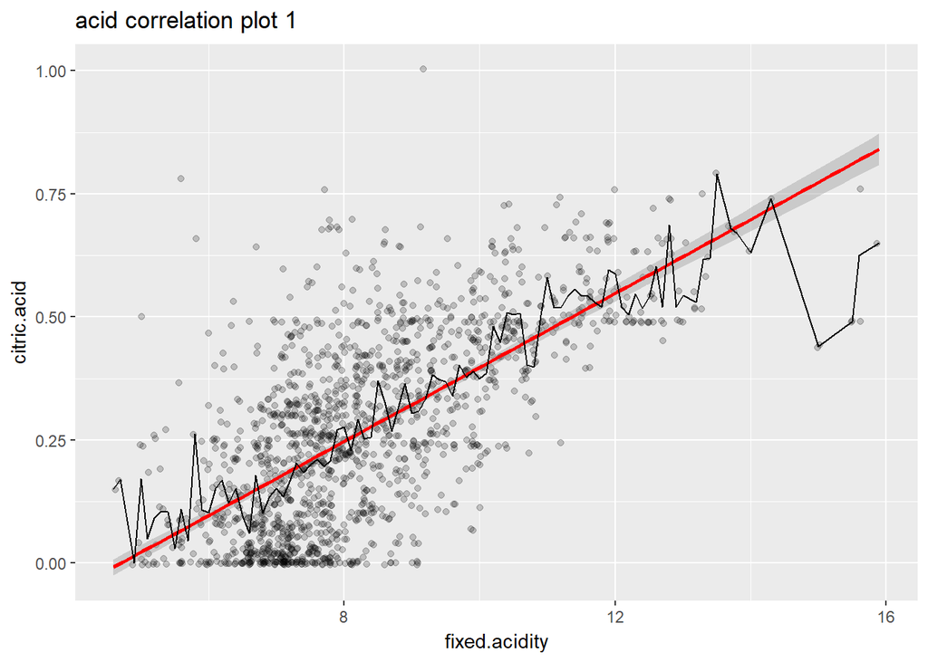

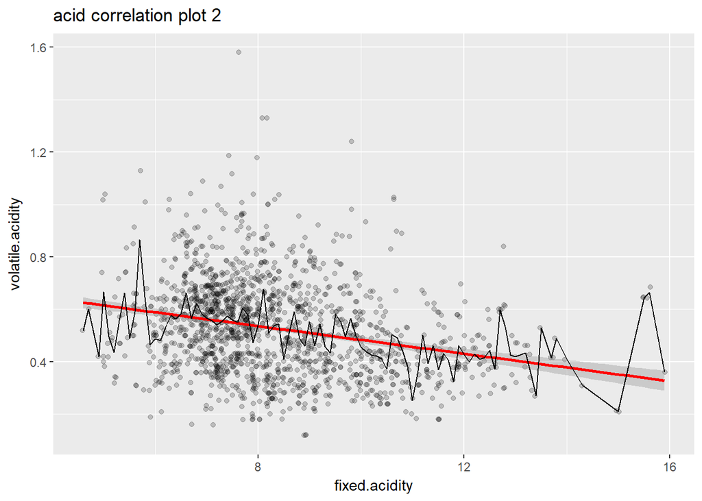

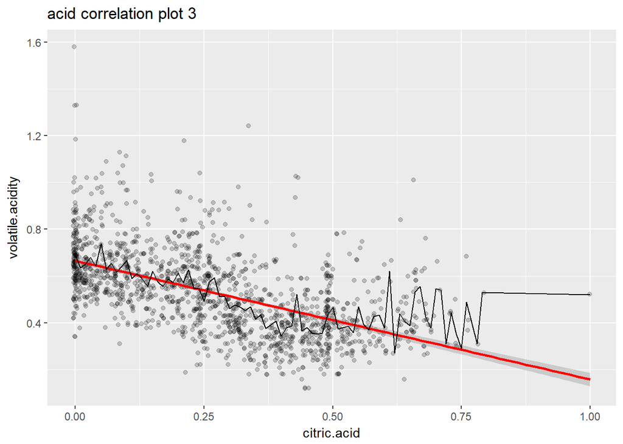

这部分我探索了几种酸性互相之间的关系。从图中我们可以清晰的看出，几种酸性之间有较大的联系，其中fixed acidity和citric acidity 关系较大，随着fixed acidity的增加， citric acidity 也随之增加。fixed acitity和volatitle acidity关系相对温和，呈负相关形态。这样的结果也和我们的因子分析基本吻合。

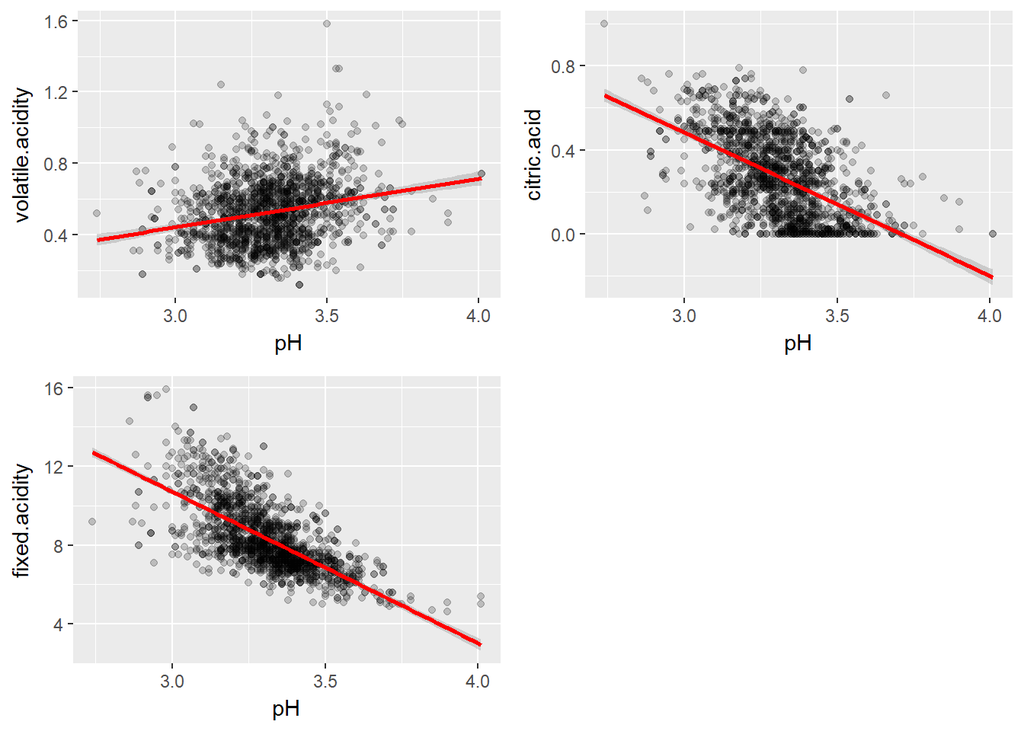

在这部分我探索了三个酸性值与pH值之间的关系，从图中我们可以看出来，三种酸性值和pH都有或多或少的关系，其中fixed acidity斜率相对最大，因此两者关系也相对较强烈， 且呈负相关。volatile acidity对Ph值影响较小。

# Bivariate Analysis

### Did you observe any interesting relationships between the other features (not the main feature(s) of interest)?

有一个让我意外的发现是，volatile acidity 和 pH值竟然是呈现正相关模式。之前我一直认为酸性物质会使pH值下降。 ### What was the strongest relationship you found? 与输出变量有关的最强的关系是，quality和alcohol之间的关系，相关参数为0.48

# Multivariate Plots Section

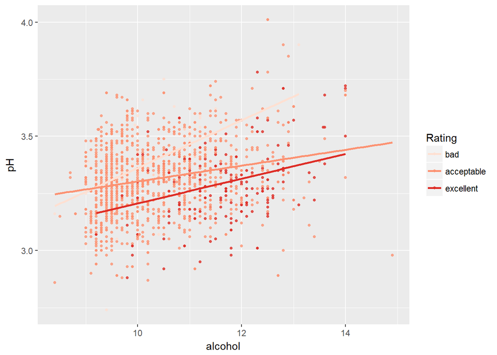

首先，我探索了不同红酒评级下，pH值和酒精度之间的关系，从图中我们可以看出，评级较高的酒通常pH值更低，酒精度数却相对较高。

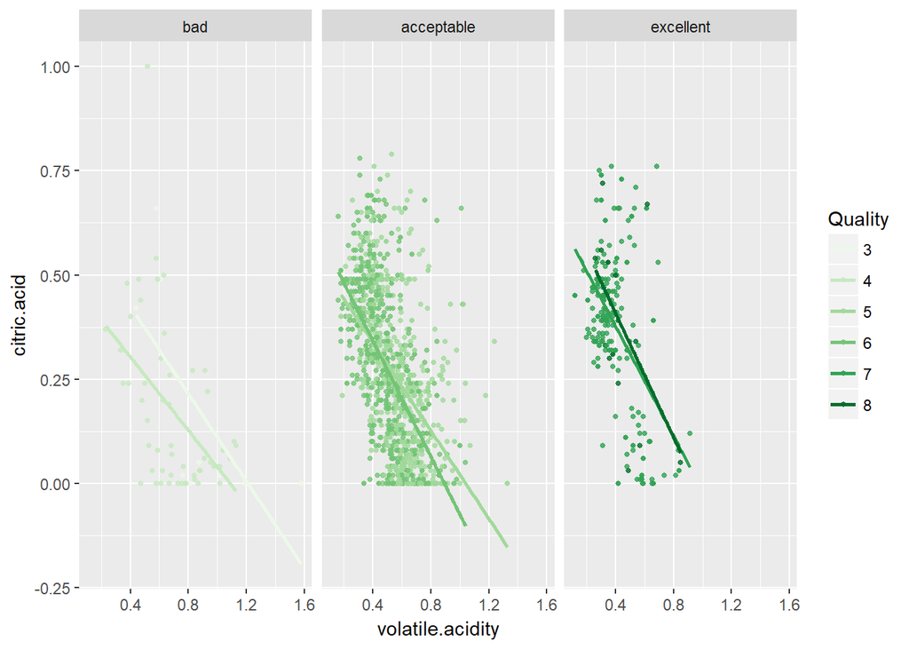

随后 我探索了不同评级，不同评分的红酒中，citric acid和volatitle acid的关系。根据图形，可以看出，在excellent评级中的红酒，较高的citric和volatitle能产出更加 优秀的红酒，然而在bad评级中，这种关系却不适用。在acceptable评级中，关系则更为复杂，图形交缠。

# Multivariate Analysis

### Talk about some of the relationships you observed in this part of the investigation. Were there features that strengthened each other in terms of looking at your feature(s) of interest?

1. 评级较高的酒通常pH值更低，酒精度数却相对较高
2. 不同评级，不同评分的红酒中，citric acid和volatile acid的关系。根据图形，可以看出，在excellent评级中的红酒，较高的citric和volatitle能产出更加 优秀的红酒，然而在bad评级中，这种关系却不适用。在acceptable评级中，关系则更为复杂，图形交缠。

### Were there any interesting or surprising interactions between features?

不同评级和评分的红酒中的，citric和volatile两种酸的关系有所不同。此前，我认为红酒不同评级中，酸性物质的规律应该呈现相同或者类似的模式。事实上， 酸性物质之间的关系却是有较大的差异。

### OPTIONAL: Did you create any models with your dataset? Discuss the strengths and limitations of your model.

模型瑕疵较大，未创建线性回归模型。

# Final Plots and Summary

### Plot One

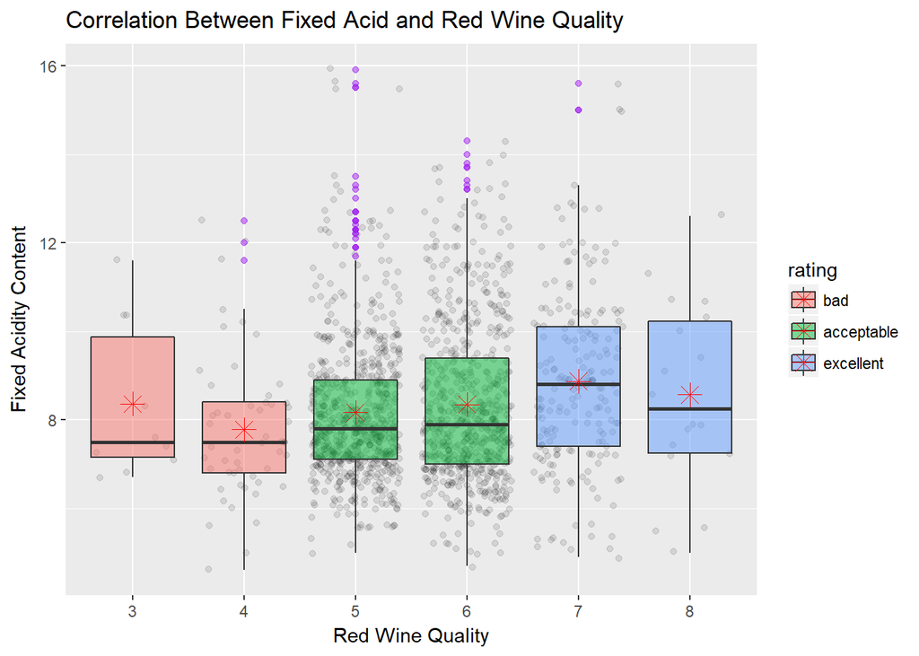

### Description One

此图探索了红酒质量和Fixed Acid之间的关系，从此图中我们可以看出红酒质量和Fixed Acidity之间并无明显关系，随着Quality的增加，Fixed Acid的值波动不明显。 此外，我们还可以看出位于Acceptable评级的红酒中，Fixed Acidity的含量离散度较高并且还含有较多的Outliner值。

### Plot Two

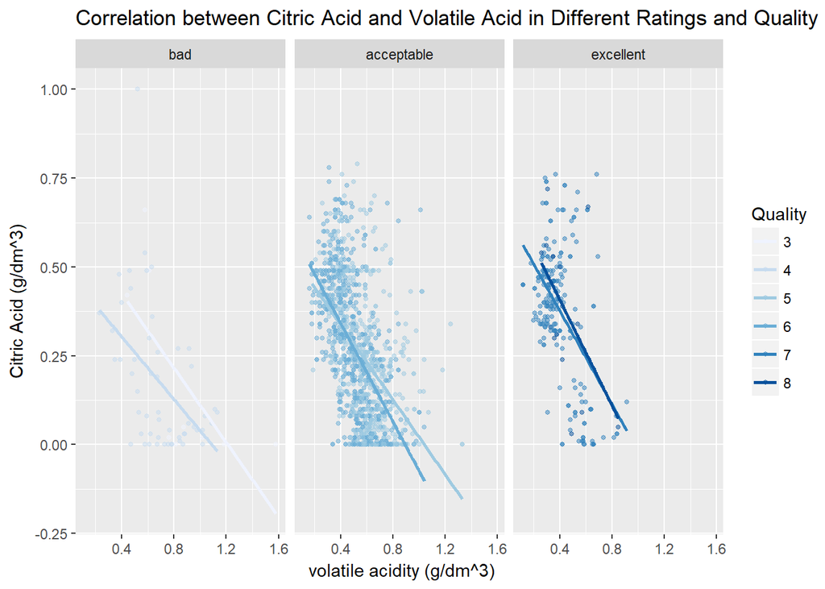

### Description Two

这幅可视化探索了不同评级，不同评分的红酒中，citric acid和volatitle acid的关系。根据图形，可以看出，在excellent评级中的红酒，根据拟合线来看，较高的citric和volatitle能产出更加 优秀的红酒，然而这种规律并不十分明显，在拟合线的末尾已经趋近于重合。然而在bad评级中，这种关系却不适用，较高的两种酸性物质值可能带来的是更加低劣的红酒。在acceptable评级中， 关系则更为复杂，图形交叉在一起。

### Plot Three

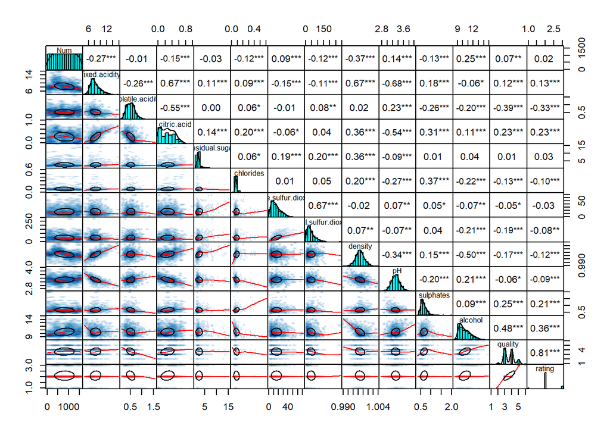

### Description Three

此图为红酒数据集的相关性矩阵，即数据集中各个数据的相关程度，图中描述并给出了红酒数据集中所有数据两两之间的相关性参数，散点图和柱状图。 矩阵的一行一列的交汇处即为两个数据的相关性参数，从图中我们可以看出，红酒质量与酒精度，sulphates和citric acid关系最大，与volatile acid负相关性最大。 图中相关性参数的后面的星号表示相关性的程度，越相关的数据后面星号越多。在散点图中添加了平滑拟合曲线以便能体现数据的走向。 ——

# Reflection

在本项目中，我遇到的第一个困难是在双变量分析时候，犹豫quality数据为离散型数据，如果直接画离散型数据和连续型数据的散点图，很难体现出数据的特征，后来 查阅了资料后，首先对离散型数据进行了数据抖动，借此来观测数据的集中趋势。此外还为图形添加了箱线图一遍观察两个变量直接的关系，通过观测一个变量相对于另一个 变量的统计数据的关系，可以对两个变量的关系有一个大概的了解。 第二个困难是在绘制多变量分析图形的时候，如果只观测quality相同下 acid值之间的关系，图形纠缠在一起很难观测出相应的规律。在调整了分面之后，可以更为清晰的 观测到数据之间的关系。例如在第二个最终绘图所示。 第三个困难是在观测volatitle acid和PH值之间的关系的时候，随着volatile acid值上升，pH值竟然随之升高，这个和我所学的化学知识相悖。后来经过查阅才发现，统计中 有一种叫Simpson’s Paradox的现象，有时候数据的走势会完全倒转。 对于未来的分析，我有一个想法。本数据集主要是包含红酒的化学成分以及最终的质量评分。我们探索了红酒质量与红酒化学成分之间的关系。由此，我联想到一个问题，红酒 的评分是由品酒师做出的，那么会不会因为品酒师经验的差异导致评分的不准确呢，所以在未来的探索中，我认为可以加入一些品酒师的相关数据，类似他们的经验，专业范围， 喜好等等。根据这些数据，我们可以排除一些由于品酒师的差异带来的数据的噪音，能够更好的进行数据探索。